# statistical analsysis for coursera project

sayonee

10/21/2020

Part A: Simulation Exercise for exploring inference

The task is for us to investigate the exponential distribution in R and compare it wit : Central Limit Theorem. The exponential distribution will be simulated in R with rexp(n,lambda) where lambda is know to be the rate parameter. The mean of exponential distribution and the standard deviation are both given as 1/lambda where we know that lambda = 0.2, and distribution of averages of 40 exponentials and will perform 1000 simulations according to the question in place.

Mean Comparision Sample Mean vs Theoretical Mean of the Distribution

```r
# Sample Mean
samplMeen <- mean(mean_simp_data1) # Mean of sample means
print (paste("Sample Mean is given by = ", samplMeen))
```

```
## [1] "Sample Mean is given by =  4.9709164233489"
```

```r
# Theoretical Mean
# the expected mean of the exponential distribution of rate is given by = 1/lambda
theory_mean1 <- (1/lambdano)
print (paste("Theoretical Mean = ", theory_mean1))
```

```
## [1] "Theoretical Mean =  5"
```

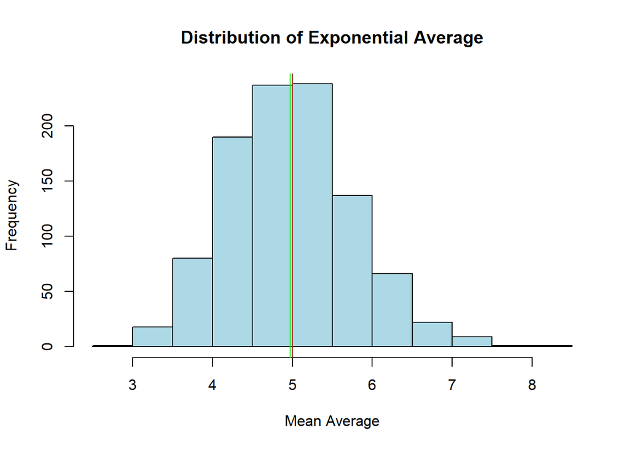

```r
# Histogram shows differences
hist(mean_simp_data1, col="light blue", xlab = "Mean Average", main="Distribution of Exponential Average")
abline(v = theory_mean1, col="brown")
abline(v = samplMeen, col="green")
```

Question 2: Is asked to Show how variable the sample can be (via variance) and we are asked to compare it with the theoretical variance of the distribution

Calculating: the theoretical and sample variance according to the given question in place

```r
# sample deviation & variance
sampl_dev1 <- sd(mean_simp_data1)
sampl_dev1
```

```
## [1] 0.7844431
```

```r
sampl_vari1<- sampl_dev1^2
sampl_vari1
```

```
## [1] 0.6153509
```

```r
# theoretical deviation & variance
theory_dev1 <- (1/lambdano)/sqrt(n)
theory_dev1
```

```
## [1] 0.7905694
```

```r
theory_var1 <- ((1/lambdano)*(1/sqrt(n)))^2
theory_var1
```

```
## [1] 0.625
```

Question 3: we are asked to Show that the distribution is approx a normal Histogram with having Density and sample means:

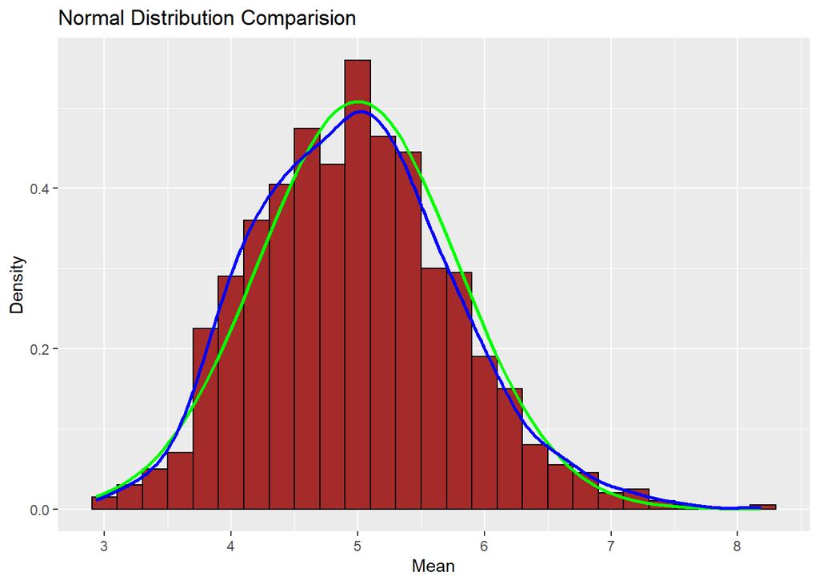

```r
dat <- data.frame(mean_simp_data1)
ther <- data.frame(theory_mean1)
ggpl<- ggplot(dat, aes(x = mean_simp_data1)) +
geom_histogram(binwidth = .2, color="black", fill="brown" , aes(y=..density..))+
 stat_function(fun=dnorm, args=list(mean=theory_mean1, sd=sd(mean_simp_data1)),
 color="green", size =1) +
 stat_density(geom = "line", color = "blue", size =1) +
 labs(x="Mean", y= "Density",
 title="Normal Distribution Comparision")
ggpl
```

we are indicating that the density curve is fairly equivalent to the normal distribution curve also predicts and indicates the normal distribution

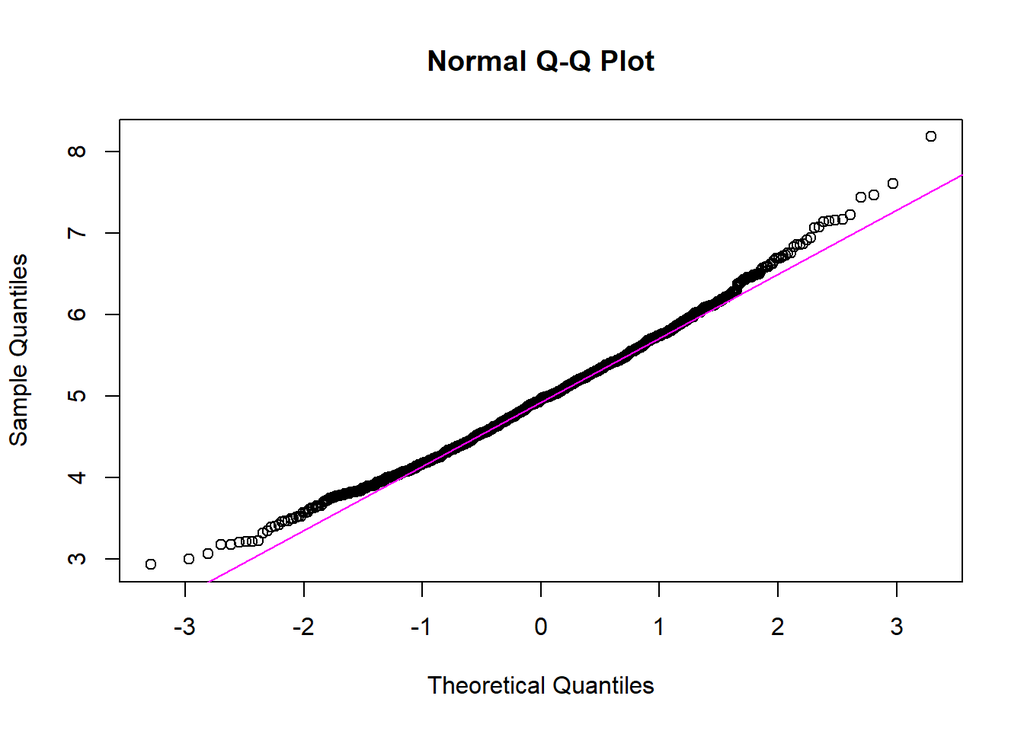

```r
qqnorm(mean_simp_data1)
qqline(mean_simp_data1, col = "magenta")
```